# Introduction to ggplot2

The most popular data visualization framework in R

PHAC R Usergroup: Basics of R Summer Camp

2025-07-23

## What is ggplot2?

`ggplot2` is the most downloaded R library in the world

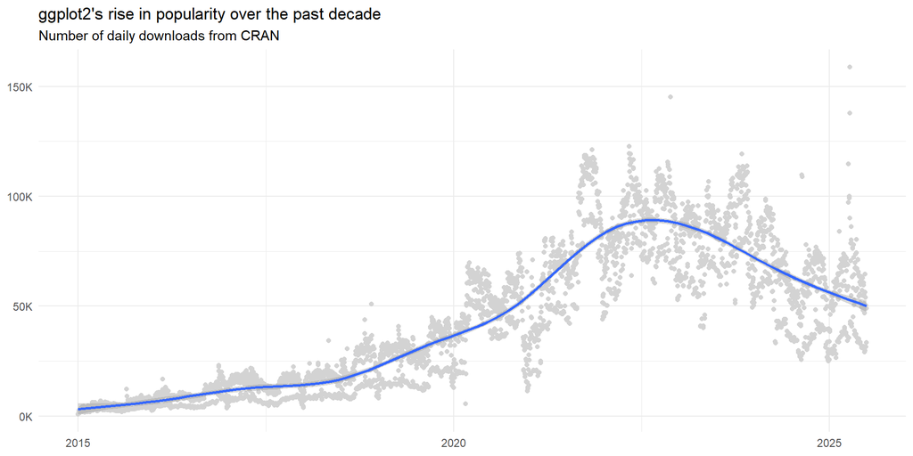

## ggplot2 overview

- Part of the `tidyverse` suite of packages, `ggplot2` offers great consistency with `dplyr` pipes and syntax <sup>1</sup>
- “gg” refers to “[The Grammar of Graphics](https://link.springer.com/book/10.1007/0-387-28695-0),” a 1999 book from Leland Wilkinson that provides a framework for creating statistical graphics in **layered components**
- The “2” in `ggplot2` alludes to the fact that this package supplants an older library simply called `ggplot`, both developed by Hadley Wickham <sup>2</sup>
[^1]: there is one very **notable exception**, which is the use of `+` instead of `%>%` to connect functions/verbs
[^2]: the main function in `ggplot2` is still called `ggplot()`

## Anatomy of a plot

https://ggplot2.tidyverse.org/articles/ggplot2.html

## Getting started - Data

```r
tail(ggplot_downloads_df)
```

```
           date count package
3829 2025-06-25 54021 ggplot2
3830 2025-06-26 50323 ggplot2
3831 2025-06-27 50306 ggplot2
3832 2025-06-28 31488 ggplot2
3833 2025-06-29 33328 ggplot2
3834 2025-06-30 48941 ggplot2
```

## Getting started - Plot

```r
library(ggplot2)

# ggplot2 needs the user to provide at least the following three components:
# data, mapping, and layer

g2 <- ggplot(ggplot_downloads_df,          # Data
             aes(x = date, y = count)) +   # Mapping
             geom_point()                  # Layer

g2
```

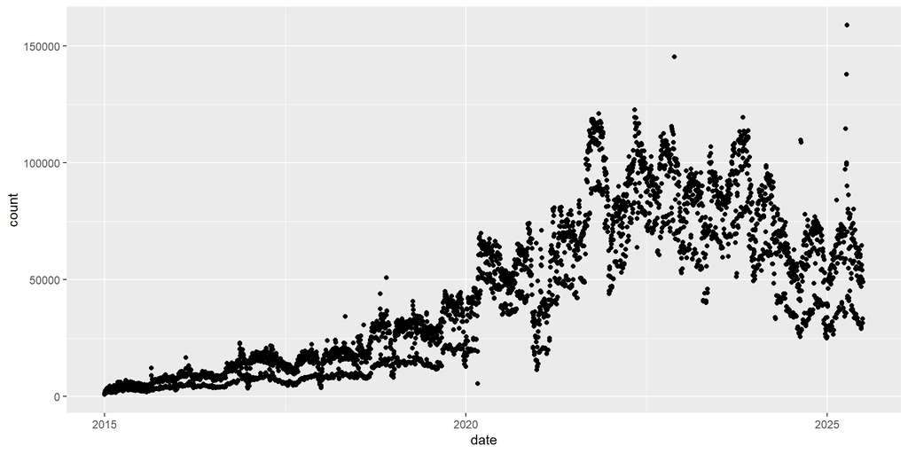

## What makes for a good plot?

- Easy to start with some minimally viable code for a plot, but how does one make a cleaner and more polished graph?
  - Ironically, more lines of code are needed for a less cluttered plot
- By utilizing rest of the components, one can add more features to the graph and also clean up unnecessary elements
- Implement some good data visualization practices <sup>1</sup>
[^3]: Author Stephanie Evergreen has a 24-point checklist on [her website](https://stephanieevergreen.com/rate-your-visualization/), and a [previous presentation](https://raw.githack.com/najsaqib/naj_lab/main/data_viz_checklist.html) in the user group shows how to incorporate that in `ggplot2`

## Polishing the plot - Adding another Geom

```r
g3 <- ggplot(ggplot_downloads_df,          # Data
             aes(x = date, y = count)) +   # Mapping
             geom_point() +                # Layer
             geom_smooth()                 # Layer (additional)

g3
```

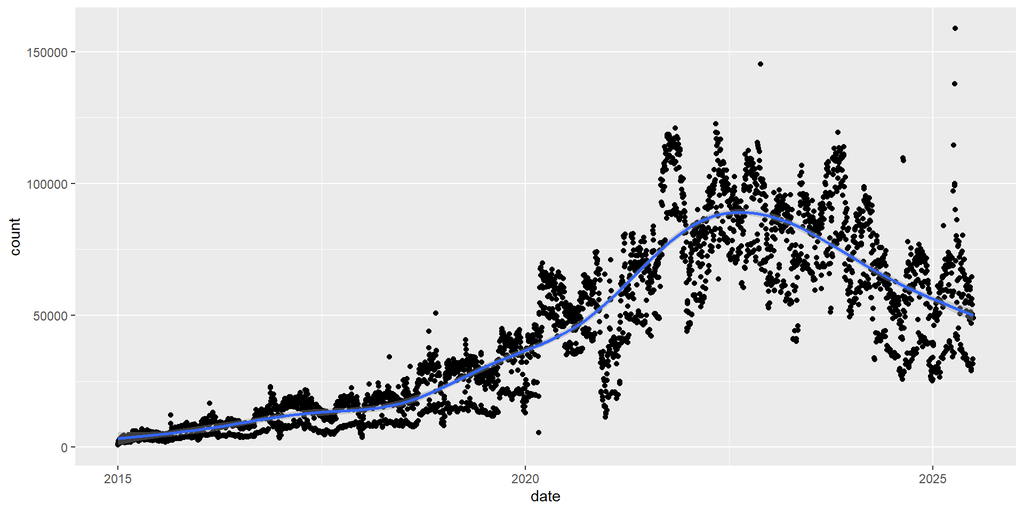

## Polishing the plot - Scaling layer

```r
library(scales)

g4 <- ggplot(ggplot_downloads_df,          # Data
             aes(x = date, y = count)) +   # Mapping
             geom_point() +                # Layer
             geom_smooth() +               # Layer (additional)
             scale_y_continuous(
               labels = label_number(
                 suffix = "K", scale = 1e-3)
               )                           # Scale

g4
```

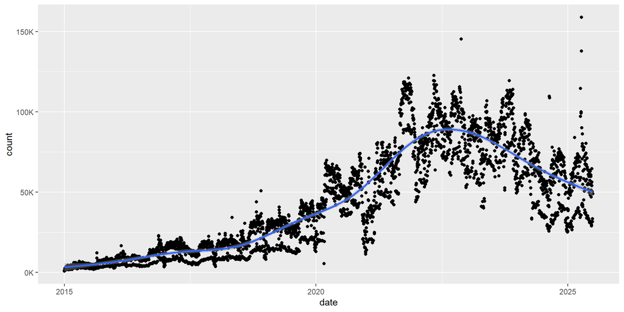

## Polishing the plot - Adding theme layer

```r
g5 <- ggplot(ggplot_downloads_df,          # Data
             aes(x = date, y = count)) +   # Mapping
             geom_point() +                # Layer
             geom_smooth() +               # Layer (additional)
             scale_y_continuous(
               labels = label_number(
                 suffix = "K", scale = 1e-3)
               ) +                         # Scale
             theme_minimal()               # Theme
g5
```

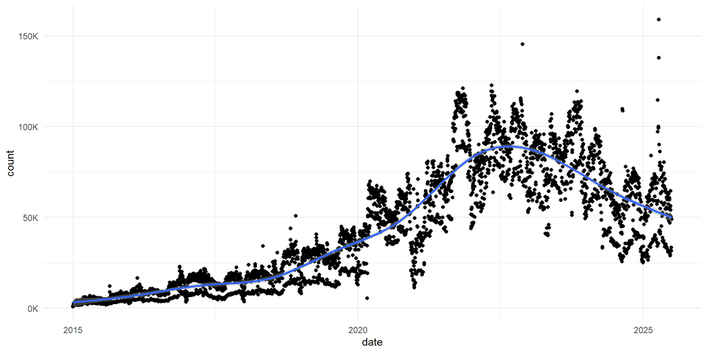

## Polishing the plot - Specifying Labels

```r
g6 <- ggplot(ggplot_downloads_df,          # Data
             aes(x = date, y = count)) +   # Mapping
             geom_point() +                # Layer
             geom_smooth() +               # Layer (additional)
             scale_y_continuous(
               labels = label_number(
                 suffix = "K", scale = 1e-3)
               ) +                         # Scale
             theme_minimal() +             # Theme
             labs(title = "ggplot2's rise in popularity over the past decade",
                  subtitle = "Number of daily downloads from CRAN",
                         x = NULL,
                         y = NULL)         # Labels
g6
```

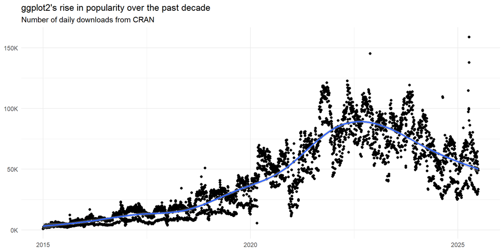

## Polishing the plot - Modifying Colour

```r
g7 <- ggplot(ggplot_downloads_df,          # Data
             aes(x = date, y = count)) +   # Mapping
             geom_point(colour = "lightgrey") + # Layer
             geom_smooth() +               # Layer (additional)
             scale_y_continuous(
               labels = label_number(
                 suffix = "K", scale = 1e-3)
               ) +                         # Scale
             theme_minimal() +             # Theme
             labs(title = "ggplot2's rise in popularity over the past decade",
                  subtitle = "Number of daily downloads from CRAN",
                         x = NULL,
                         y = NULL)         # Labels
g7
```

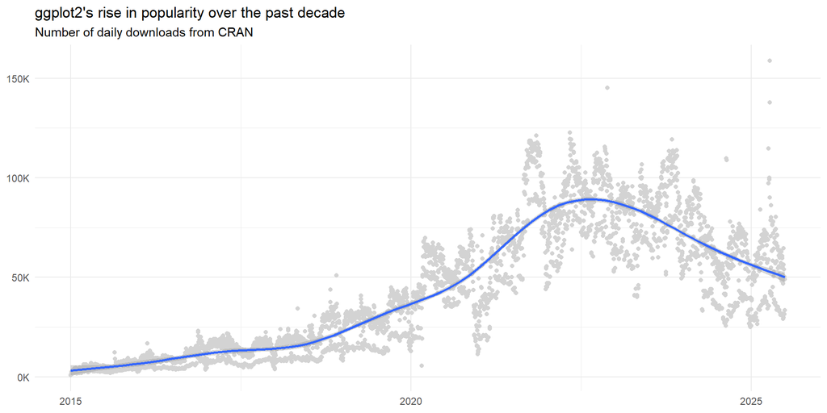

## From start to finish

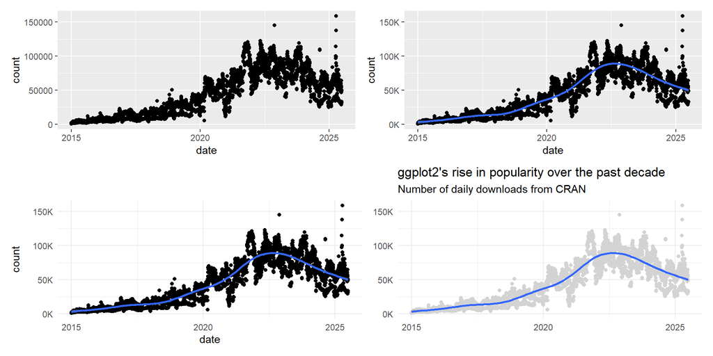

## Where to go from here?

- Experiment with different types of graphs
- Change default parameters
- Learn how to incorporate `ggplot2` graphs in R Markdown/Quarto outputs
- Implement reactive `ggplot2` objects within Shiny apps
- Explore interactive plots via `ggiraph` or `ggplotly` packages
- Compare and contrast `ggplot2` with base R or different libraries
- Match Government of Canada look and feel
- Make visuals colour-blind friendly and generally compliant with accessibility standards

## Example plot types

https://ouyanglab.com/covid19dataviz/ggplot2.html

## Resources

- Official website: https://ggplot2.tidyverse.org/index.html
- Cheat sheet: https://github.com/rstudio/cheatsheets/blob/main/data-visualization.pdf
- Book of common plots: https://r-graphics.org/
- Example graphs (includes non-`ggplot2` examples): https://r-graph-gallery.com/
- Good data visualization practices by Stephanie Evergreen: https://www.datavisualizationchecklist.com/
- Implementing Stephanie Evergreen checklist in `ggplot2`: https://github.com/PHAC-RUG/presentations/blob/main/2021/ggplot_best_practices/data_viz_checklist.rmd
- Link to this document (Quarto Markdown): https://github.com/PHAC-RUG/presentations/blob/main/2025/intro_ggplot2/intro_ggplot2.qmd
- Link to this document (HTML): https://raw.githack.com/PHAC-RUG/presentations/main/2025/intro_ggplot2/intro_ggplot2.html